# Biostat 212A Homework 3

Due Feb 20, 2024 @ 11:59PM

Author

Jiyin (Jenny) Zhang, 606331859

Published

February 20, 2024

## 1 ISL Exercise 5.4.2 (10pts)

We will now derive the probability that a given observation is part of a bootstrap sample. Suppose that we obtain a bootstrap sample from a set of $n$ observations.

**(a)** What is the probability that the first bootstrap observation is $not$ the $j$th observation from the original sample? Justify your answer.

**Answer:** $1−1/n$

The probability that the first bootstrap observation is not the $j$th observation from the original sample is $1−1/n$. This is because there are $n$ samples, and we are equally likely to pick each observation when taking our first bootstrap observation.

**(b)** What is the probability that the second bootstrap observation is not the $j$th observation from the original sample?

**Answer:** $1−1/n$

Since bootstrap observations are sampled from the original observations with replacement, the probability that the second bootstrap observation is not the $j$th observation from the original sample is again $1−1/n$.

**(c)** Argue that the probability that the $j$th observation is $not$ in the bootstrap sample is $(1 − 1/n)^n$.

**Answer:**

The probability that the $j$th observation is not in the bootstrap sample is $(1 − 1/n)^n$. This is because the probability that the $j$th observation is not in the bootstrap sample is the same as the probability that the first bootstrap observation is not the $j$th observation from the original sample, multiplied by the probability that the second bootstrap observation is not the $j$th observation from the original sample, and so on, up to the $n$th bootstrap observation. Since each of these probabilities is $(1 − 1/n)$, the probability that the $j$th observation is not in the bootstrap sample is $(1 − 1/n)^n$. Note that we are multiplying probabilities because sampling with replacement means that the individual bootstrap observations in the bootstrap sample are independent.

**(d)** When $n$ = 5, what is the probability that the $j$th observation is in the bootstrap sample?

**Answer:**

When $n$ = 5, the probability that the $j$th observation is in the bootstrap sample is $1−(1−1/5)^5 = 1−(4/5)^5 = 1−0.32768 = 0.67232$.

**(e)** When $n$ = 100, what is the probability that the $j$th observation is in the bootstrap sample?

**Answer:**

When $n$ = 100, the probability that the $j$th observation is in the bootstrap sample is $1−(1−1/100)^100 = 1−(99/100)^100 = 1−0.36603 = 0.63397$.

**(f)** When $n$ = 10,000, what is the probability that the $j$th observation is in the bootstrap sample?

**Answer:**

When $n$ = 10,000, the probability that the $j$th observation is in the bootstrap sample is $1−(1−1/10000)^10000 = 1−(9999/10000)^10000 = 1−0.36769 = 0.63231$.

**(g)** Create a plot that displays, for each integer value of $n$ from 1 to 100,000, the probability that the $j$th observation is in the bootstrap sample. Comment on what you observe.

**Answer:**

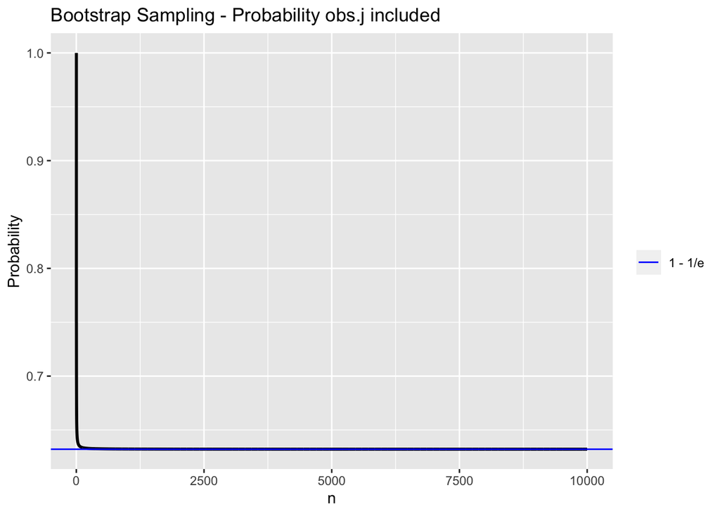

```r
library(dplyr)
library(ggplot2)

n <- 1:10000

data.frame(n, prob_j_included = 1 - (1 - 1/n)^n) %>%
  ggplot(aes(x = n, y = prob_j_included)) +
  geom_line(size = 1) +
  geom_hline(aes(yintercept = 1 - 1/exp(1), col = "1 - 1/e")) +
  scale_color_manual(values = c("blue")) +
  labs(title = "Bootstrap Sampling - Probability obs.j included", y = "Probability", col = "")
```

We are seeing a visual representation of $\lim_\limits{n\to \infty} {1−(1−\frac{1}{n})^n}=1−\frac1e≈0.632$, which is the reason why this is sometimes called the 0.632 rule in bootstrapping. This is the probability that the $j$th observation is in the bootstrap sample.

**(h)** We will now investigate numerically the probability that a bootstrap sample of size $n$ = 100 contains the $j$th observation. Here $j$ = 4. We repeatedly create bootstrap samples, and each time we record whether or not the fourth observation is contained in the bootstrap sample.

```r
store <- rep(NA, 10000)
for (i in 1:10000) {
  store[i] <- sum(sample(1:100, rep = TRUE) == 4) > 0
}
mean(store)
```

```
[1] 0.6344
```

Comment on the results obtained.

**Answer:**

To relate this to previous questions, we created 10,000 separate bootstrap samples, sampling from the set of integers from 1 to 100: {1,2,…,100}.

In the `sample()` function there is a `size` argument, and since we did not set this, the default behavior is to sample n = 100 items from the vector x = 1:100. `replace = TRUE` means that this sampling occurs with replacement. This occurs for each $i$ in the loop.

`sum(sample(1:100, rep=TRUE) == 4) > 0` checks whether any of these 100 items were the number 4 (this is our $j$ in previous questions), returning TRUE if 4 was within the sample, else FALSE.

Assigning this to `store[i]` stores this result in the $i$th position of the vector store. This happens 10,000 times (one for each bootstrap sample), so the resulting store vector is logical with 10,000 entries.

At the end the mean is calculated, which for a logical vector will give the proportion of the 10,000 entries in store that had value `TRUE = 1`.

We create 10,000 bootstrap samples from {1,2,…,100}, then calculate what proportion of them contained 4.

Wwe would expect that if we perform many many bootstrap samples, around 63.2% of them will contain the number 4.

## 2 ISL Exercise 5.4.9 (20pts)

We will now consider the Boston housing data set, from the ISLR2 library.

**(a)** Based on this data set, provide an estimate for the population mean of `medv`. Call this estimate $\hat\mu$.

**Answer:**

```r
library(ISLR2)
data("Boston")
head(Boston)
```

```
     crim zn indus chas   nox    rm  age    dis rad tax ptratio lstat medv
1 0.00632 18  2.31    0 0.538 6.575 65.2 4.0900   1 296    15.3  4.98 24.0
2 0.02731  0  7.07    0 0.469 6.421 78.9 4.9671   2 242    17.8  9.14 21.6
3 0.02729  0  7.07    0 0.469 7.185 61.1 4.9671   2 242    17.8  4.03 34.7
4 0.03237  0  2.18    0 0.458 6.998 45.8 6.0622   3 222    18.7  2.94 33.4
5 0.06905  0  2.18    0 0.458 7.147 54.2 6.0622   3 222    18.7  5.33 36.2
6 0.02985  0  2.18    0 0.458 6.430 58.7 6.0622   3 222    18.7  5.21 28.7
```

```r
mu_hat <- mean(Boston$medv)
cat("The population mean of medv is:", mu_hat, "\n")
```

```
The population mean of medv is: 22.53281
```

**(b)** Provide an estimate of the standard error of $\hat\mu$. Interpret this result. Hint: We can compute the standard error of the sample mean by dividing the sample standard deviation by the square root of the number of observations.

**Answer:**

```r
se_mu_hat <- sd(Boston$medv) / sqrt(length(Boston$medv))
cat(
  "The estimate of the standard error of the population mean of medv is:",
  se_mu_hat,
  "\n"
)
```

```
The estimate of the standard error of the population mean of medv is: 0.4088611
```

**(c)** Now estimate the standard error of $\hat\mu$ using the bootstrap. How does this compare to your answer from (b)?

**Answer:**

```r
# Install the boot package if you haven't already
# install.packages("boot")
# Load the boot package
library(boot)
```

```r
set.seed(1)
boot.fn <- function(data, index) {
  mu <- mean(data[index])
  return(mu)
}
boot(Boston$medv, boot.fn, 1000)
```

```
ORDINARY NONPARAMETRIC BOOTSTRAP


Call:
boot(data = Boston$medv, statistic = boot.fn, R = 1000)


Bootstrap Statistics :
    original      bias    std. error
t1* 22.53281 0.007650791   0.4106622
```

The bootstrap estimated standard error of $\hat\mu$ is very close to the estimate found in (b).

**Answer:**

```r
# Calculate the 95% confidence interval using the formula
standard_error <- 0.4106622
ci_lower <- mu_hat - 2 * standard_error
ci_upper <- mu_hat + 2 * standard_error
cat(
  "The 95% confidence interval for the mean of medv is: (",
  ci_lower,
  ",",
  ci_upper,
  ")\n"
)
```

```
The 95% confidence interval for the mean of medv is: ( 21.71148 , 23.35413 )
```

```r
# Compare it to the results obtained using t.test(Boston$medv)
t.test(Boston$medv)
```

```
    One Sample t-test

data:  Boston$medv
t = 55.111, df = 505, p-value < 2.2e-16
alternative hypothesis: true mean is not equal to 0
95 percent confidence interval:
 21.72953 23.33608
sample estimates:
mean of x
 22.53281
```

The bootstrap confidence interval is very close to the one provided by the `t.test()` function.

**(e)** Based on this data set, provide an estimate, $\hat\mu_{med}$, for the median value of `medv` in the population.

**Answer:**

```r
mu_med_hat <- median(Boston$medv)
cat(
  "The estimate for the median value of medv in the population is:",
  mu_med_hat,
  "\n"
)
```

```
The estimate for the median value of medv in the population is: 21.2
```

**(f)** We now would like to estimate the standard error of $\hat\mu_{med}$. Unfortunately, there is no simple formula for computing the standard error of the median. Instead, estimate the standard error of the median using the bootstrap. Comment on your findings.

**Answer:**

```r
set.seed(1)
boot.fn <- function(data, index) {
  mu_med <- median(data[index])
  return(mu_med)
}
boot(Boston$medv, boot.fn, 1000)
```

```
ORDINARY NONPARAMETRIC BOOTSTRAP


Call:
boot(data = Boston$medv, statistic = boot.fn, R = 1000)


Bootstrap Statistics :
    original  bias    std. error
t1*     21.2 0.02295   0.3778075
```

We get an estimated median value of 21.2 which is equal to the value obtained in (e), with a standard error of 0.3778075 which is relatively small compared to median value.

**(g)** Based on this data set, provide an estimate for the tenth percentile of `medv` in Boston census tracts. Call this quantity $\hat\mu_{0.1}$. (You can use the quantile() function.)

**Answer:**

```r
mu_0.1_hat <- quantile(Boston$medv, 0.1)
cat(
  "The estimate for the tenth percentile of medv in the population is:",
  mu_0.1_hat,
  "\n"
)
```

```
The estimate for the tenth percentile of medv in the population is: 12.75
```

**(h)** Use the bootstrap to estimate the standard error of $\hat\mu_{0.1}$. Comment on your findings.

**Answer:**

```r
set.seed(1)
boot.fn <- function(data, index) {
  mu_0.1 <- quantile(data[index], 0.1)
  return(mu_0.1)
}
boot(Boston$medv, boot.fn, 1000)
```

```
ORDINARY NONPARAMETRIC BOOTSTRAP


Call:
boot(data = Boston$medv, statistic = boot.fn, R = 1000)


Bootstrap Statistics :
    original  bias    std. error
t1*    12.75  0.0339   0.4767526
```

We get an estimated tenth percentile value of 12.75 which is again equal to the value obtained in (g), with a standard error of 0.4767526 which is relatively small compared to the tenth percentile value.

## 3 Least squares is MLE (10pts)

Show that in the case of linear model with Gaussian errors, maximum likelihood and least squares are the same thing, and $C_p$ and AIC are equivalent.

**Answer:**

The linear model with Gaussian errors is given by

$$Y = X\beta + \epsilon$$

where $\epsilon \sim N(0, \sigma^2)$.

The likelihood function is given by

$$L(\beta, \sigma^2) = \prod_{i=1}^n \frac{1}{\sqrt{2\pi\sigma^2}} \exp\left(-\frac{(Y - X\beta)^T*(Y - X\beta)}{2\sigma^2}\right)$$

The log-likelihood function is given by

$$\ell(\beta, \sigma^2) = -\frac{n}{2} \log(2\pi) - \frac{n}{2} \log(\sigma^2) - \frac{1}{2\sigma^2} (Y - X\beta)^T*(Y - X\beta)$$

Compute the derivative of $\beta$ with respect to $(Y - X)^T*(Y - X) $

$$\begin{align*}
\frac{\partial}{\partial\beta} (Y - X\beta)^T*(Y - X\beta)
&= \frac{\partial}{\partial\beta} (Y^TY - Y^TX\beta - \beta^TX^TY + \beta^TX^TX\beta) \\
&= \frac{\partial}{\partial\beta} (Y^TY - 2\beta^TX^TY - \beta^TX^TX\beta) \\
&= -2 X^T Y +2 X^T X\beta \\
&= -2 X^T (Y - X \beta) \\
\end{align*}$$

Then compute the derivative of $\beta$ with respect to $l(\beta,\sigma^2)$

$$\begin{align*}
\frac{\partial}{\partial\beta} \ell(\beta, \sigma^2)
&= \frac{\partial}{\partial\beta} \left(-\frac{n}{2} \log(2\pi) - \frac{n}{2} \log(\sigma^2) - \frac{1}{2\sigma^2} (Y - X\beta)^T*(Y - X\beta)\right) \\
&= \frac{\partial}{\partial\beta} \left(-\frac{1}{2\sigma^2} (Y - X\beta)^T*(Y - X\beta)\right) \\
&= \frac{1}{2\sigma^2} 2 X^T (Y - X \beta) \\
\end{align*}$$

Set the derivative of $\beta$ with respect to $l(\beta,\sigma^2)$ to zero

$$\begin{align*}
\frac{1}{2\sigma^2} 2 X^T (Y - X \beta) &= 0 \\
X^T (Y - X \beta) &= 0 \\
X^T Y - X^T X \beta &= 0 \\
X^T Y = X^T X \beta \\
\end{align*}$$

Solve for $\beta$

$$\hat\beta = (X^TX)^{-1}X^TY$$

and as for $\sigma^2$

$$\sigma^2 = \frac{1}{n} (Y - X\beta)^2$$

The least squares estimates are given by

$$\hat\beta = (X^TX)^{-1}X^TY$$

Therefore, maximum likelihood and least squares are the same thing.

Here is $C_p$

$$\begin{align*}
C_p &= \frac{1}{n} \left(\text{RSS} + 2d\hat\sigma^2\right) \\
\end{align*}$$
Assume that

$$\hat\sigma^2 = \sigma^2$$

Therefore,

$$C_p = \frac{1}{n} \left(\text{RSS} + 2d\sigma^2\right)$$

and here is AIC

$$\begin{align*}
AIC &= -2logL + 2d \\
&= -2\left(-\frac{n}{2} \log(2\pi) - \frac{n}{2} \log(\sigma^2) - \frac{1}{2\sigma^2} (Y - X\beta)^T*(Y - X\beta)\right) + 2d \\
&= n\log(2\pi) + n\log(\sigma^2) +\frac{1}{\sigma^2} (Y - X\beta)^T*(Y - X\beta) + 2d \\
&= n\log(2\pi) + n\log(\sigma^2) +\frac{1}{\sigma^2} RSS + 2d \\
\end{align*}$$

where $\text{RSS} = (Y - X\beta)^T*(Y - X\beta)$ and $d$ is the number of predictors.

Since $n\log(2\pi)$ and $n\log(\sigma^2)$ are constants and thus the model selection depends only on the term $\frac{1}{\sigma^2} RSS$ and $2d$. We ingore the constant terms and rewrite AIC:

$$AIC \approx \frac{1}{\sigma^2} RSS + 2d$$

Multiply $AIC$ by $\frac{\sigma^2}{n}$:

$$\frac{\sigma^2}{n} * AIC = \frac{\sigma^2}{n} (\frac{1}{\sigma^2} RSS + 2d)= \frac{1}{n} (RSS + 2d\sigma^2) = C_p$$

Therefore, $C_p$ and AIC are equivalent in the function of model selection.

## 4 ISL Exercise 6.6.1 (10pts)

We perform best subset, forward stepwise, and backward stepwise selection on a single data set. For each approach, we obtain p + 1 models, containing 0, 1, 2, …, p predictors. Explain your answers:

**(a)** Which of the three models with k predictors has the smallest training RSS?

**Answer:**

The model with best subset selection has the smallest training RSS since it considers every possible model with k predictors.

**(b)** Which of the three models with k predictors has the smallest test RSS?

**Answer:**

Providing an accurate assessment is challenging based on the information available. Best subset may have the smallest test RSS because it considers more models. However when n is relatively small compared to p, the best subset might experience overfitting. Additionally, the other two methods could accidentally select a model that performs better on the test set.

**(c)** True or False:

1. The predictors in the k-variable model identified by forward stepwise are a subset of the predictors in the (k+1)-variable model identified by forward stepwise selection.

**Answer:** TRUE

In each step, forward stepwise augments with one additional predictor, hence the statement is true.

2. The predictors in the k-variable model identified by backward stepwise are a subset of the predictors in the (k + 1)-variable model identified by backward stepwise selection.

**Answer:** TRUE

In each step the backward stepwise the least useful predictor is removed, hence the answer is true.

3. The predictors in the k-variable model identified by backward stepwise are a subset of the predictors in the (k + 1)-variable model identified by forward stepwise selection.

**Answer:** FALSE

Forward and backward stepwise are independent functions, thus the above statement is false.

4. The predictors in the k-variable model identified by forward stepwise are a subset of the predictors in the (k+1)-variable model identified by backward stepwise selection.

**Answer:** FALSE

Forward and backward stepwise are independent functions, thus the above statement is false.

22. The predictors in the k-variable model identified by best subset are a subset of the predictors in the (k + 1)-variable model identified by best subset selection.

**Answer:** FALSE

Best subset chooses the best model for each k, therefore the above statement is false.

## 5 ISL Exercise 6.6.3 (10pts)

Suppose we estimate the regression coefficients in a linear regression model by minimizing

$\sum_{i=1}^{n}(y_i - \beta_0 - \sum_{j=1}^{p}\beta_jx_{ij})^2$ subject to $\sum_{j=1}^{p}|\beta_j| \le s$

for a particular value of $s$. For parts (a) through (e), indicate which of i. through v. is correct. Justify your answer.

**(a)** As we increase $\lambda$ from 0, the training RSS will:

1. Increase initially, and then eventually start decreasing in an inverted U shape.
2. Decrease initially, and then eventually start increasing in a U shape.
3. Steadily increase.
4. Steadily decrease.
5. Remain constant.

**Answer:** iv. Steadily decrease.

When s=0, we have the intercept, which is the expected mean value. As s→∞, we end up with a standard least squares. We should see a decrease in the bias and therefore a steady decrease in the training RSS as we approach a least squares regression.

**(b)** Repeat (a) for test RSS.

**Answer:** ii. Decrease initially, and then eventually start increasing in a U shape.

When s=0, we have a very high test RSS. As s increases we see the model start to fit the test data and thus the test RSS decreases. However there is a point where the variance starts to increase faster than the bias is decreasing and it starts to overfit the training data. At this point the test RSS will start to increase again.

**(c)** Repeat (a) for variance.

**Answer:** iii. Steadily increase.

When s=0 the variance is very low. As s increases, the variance steadily increases as the model starts to fit the training data.

**(d)** Repeat (a) for (squared) bias.

**Answer:** iv. Steadily decrease.

When s=0, the bias is very high, and as s increases the bias steadily decreases as the model fits the training data better.

**(e)** Repeat (a) for the irreducible error.

**Answer:** v. Remain constant.

The irreducible error is a constant and does not change as s increases and it is by definition independent of the model. Therefore it is independent of the value of s.

## 6 ISL Exercise 6.6.4 (10pts)

Suppose we estimate the regression coefficients in a linear regression model by minimizing

for a particular value of !. For parts (a) through (e), indicate which of i. through v. is correct. Justify your answer.

**(a)** As we increase $\lambda$ from 0, the training RSS will:

1. Increase initially, and then eventually start decreasing in an inverted U shape.
2. Decrease initially, and then eventually start increasing in a U shape.
3. Steadily increase.
4. Steadily decrease.
5. Remain constant.

**Answer:** iii. Steadily increase.

When $\lambda = 0$, we have the standard partial least squares. As λ→∞, we are applying a shrinking penalty which is small when βj is close to zero and therefore shrinks $\beta_j$ close to zero. As $\lambda$ increases, the bias increases and thus we should see a steady increase in the training RSS.

**(b)** Repeat (a) for test RSS.

**Answer:** ii. Decrease initially, and then eventually start increasing in a U shape.

As we increase $\lambda$, we’ll see an increase in bias but a decrease in variance up until a point where the coefficients are shrunk too. At the end of the scale when $\lambda\rightarrow\infty$, we approach the null model. Therefore we should see an initial decrease in the test RSS up to a point, then an increase in the test RSS.

**(c)** Repeat (a) for variance.

**Answer:** iv. Steadily decrease.

As we constrain the coefficients we see the variance steadily decrease.

**(d)** Repeat (a) for (squared) bias.

**Answer:** iii. Steadily increase.

As we constrain the coefficients we see a steady increase in the bias.

**(e)** Repeat (a) for the irreducible error.

**Answer:** v. Remain constant.

The irreducible error is independent of the model and therefore is a constant.

## 7 ISL Exercise 6.6.5 (10pts)

It is well-known that ridge regression tends to give similar coefficient values to correlated variables, whereas the lasso may give quite different coefficient values to correlated variables. We will now explore this property in a very simple setting.

Suppose that n = 2, p = 2, $x_{11} = x_{12}$, $x_{21} = x_{22}$. Furthermore, suppose that $y_1 + y_2 = 0$ and $x_{11} + x_{21} = 0$ and $x_{12} + x_{22} =0$, so that the estimate for the intercept in a least squares, ridge regression, or lasso model is zero: $\hat\beta_0 = 0$.

**(a)** Write out the ridge regression optimization problem in this setting.

**Answer:**

In general, the ridge regression optimization problem is given by

$$min[\sum_{i=1}^{n}(y_i - \beta_0 - \sum_{j=1}^{p}\beta_jx_{ij})^2 + \lambda\sum_{j=1}^{p}\beta_j^2]$$

In this case, $\hat\beta_0 = 0$ and $n=p=2$. So, the optimization simplifies to

$$min[(y_1 - \hat\beta_1 x_{11} - \hat\beta_2 x_{12})^2 + (y_2 - \hat\beta_1 x_{21} - \hat\beta_2 x_{22})^2 + \lambda( \hat\beta_1^2 + \hat\beta_2^2)]$$

We know the following: $x_{11} = x_{12}$, so we’ll call that $x_1$, and $x_{21} = x_{22}$, so we’ll call that $x_2$. Plugging in the values we know, we get

$$min[(y_1 - \hat\beta_1 x_1 - \hat\beta_2 x_1)^2 + (y_2 - \hat\beta_1 x_2 - \hat\beta_2 x_2)^2 + \lambda( \hat\beta_1^2 + \hat\beta_2^2)]$$

**(b)** Argue that in this setting, the ridge coefficient estimates satisfy $\hat\beta_1=\hat\beta_2$.

**Answer:**

Taking the partial derivatives of the ridge regression optimization problem with respect to $\hat\beta_1$ and $\hat\beta_2$ and setting them equal to zero, we get

$$\frac{\partial}{\partial\hat\beta_1} = 0 \rightarrow -2x_1(y_1 - \hat\beta_1 x_1 - \hat\beta_2 x_1) - 2x_2(y_2 - \hat\beta_1 x_2 - \hat\beta_2 x_2) + 2\lambda\hat\beta_1 = 0$$

$$-2x_1(y_1 - \hat\beta_1 x_1 - \hat\beta_2 x_1) - 2x_2(y_2 - \hat\beta_1 x_2 - \hat\beta_2 x_2) = - 2\lambda\hat\beta_1$$

and

$$\frac{\partial}{\partial\hat\beta_2} = 0 \rightarrow -2x_1(y_1 - \hat\beta_1 x_1 - \hat\beta_2 x_1) - 2x_2(y_2 - \hat\beta_1 x_2 - \hat\beta_2 x_2) + 2\lambda\hat\beta_2 = 0$$

$$-2x_1(y_1 - \hat\beta_1 x_1 - \hat\beta_2 x_1) - 2x_2(y_2 - \hat\beta_1 x_2 - \hat\beta_2 x_2) = - 2\lambda \hat\beta_2$$

Since the left side of the equations are the same, we can assume the right sides equal each other, so

$$- 2\lambda\hat\beta_1 = - 2\lambda\hat\beta_2$$

Thus, we can conclude that in this setting, the ridge coefficient estimates

$$\hat\beta_1 = \hat\beta_2$$

**(c)** Write out the lasso optimization problem in this setting.

**Answer:**

The lasso optimization problem is given by

$$min[\sum_{i=1}^{n}(y_i - \beta_0 - \sum_{j=1}^{p}\beta_jx_{ij})^2 + \lambda\sum_{j=1}^{p}|\beta_j|]$$

In this case, $\hat\beta_0 = 0$ and $n=p=2$. So, the optimization simplifies to

$$min[(y_1 - \hat\beta_1 x_{11} - \hat\beta_2 x_{12})^2 + (y_2 - \hat\beta_1 x_{21} - \hat\beta_2 x_{22})^2 + \lambda( |\hat\beta_1| + |\hat\beta_2|)]$$

We know the following: $x_{11} = x_{12}$, so we’ll call that $x_1$, and $x_{21} = x_{22}$, so we’ll call that $x_2$. Plugging in the values we know, we get

$$min[(y_1 - \hat\beta_1 x_1 - \hat\beta_2 x_1)^2 + (y_2 - \hat\beta_1 x_2 - \hat\beta_2 x_2)^2 + \lambda( |\hat\beta_1| + |\hat\beta_2|)]$$

**(d)** Argue that in this setting, the lasso coefficients $\hat\beta_1$ and $\hat\beta_2$ are not unique—in other words, there are many possible solutions to the optimization problem in (c). Describe these solutions.

**Answer:**

The lasso optimization problem is given by

$$min[(y_1 - \hat\beta_1 x_1 - \hat\beta_2 x_1)^2 + (y_2 - \hat\beta_1 x_2 - \hat\beta_2 x_2)^2 + \lambda( |\hat\beta_1| + |\hat\beta_2|)]$$

One way to demonstrate that these solutions are not unique is to make a geometric argument. To make things easier, we’ll use the alternate form of Lasso constraints, namely: $|\hat\beta_1| + |\hat\beta_2| < s$. If we were to plot these constraints, they take the familiar shape of a diamond centered at the origin (0, 0).

Next we’ll consider the squared optimization constraint, namely:

Using the facts we were given regarding the equivalence of many of the variables, we can simplify down to the following optimization:

$$min\ 2[y_1 - (\hat\beta_1 + \hat\beta_2 )x_1]^2$$

Taking the derivative of this with respect to $\hat\beta_1 + \hat\beta_2$ and setting it equal to zero, we get

$$\frac{\partial}{\partial(\hat\beta_1 + \hat\beta_2)} = 0 \rightarrow 2[y_1 - (\hat\beta_1 + \hat\beta_2 )x_1](-x_1) = 0$$

$$y_1 - (\hat\beta_1 + \hat\beta_2 )x_1 = 0$$

$$\hat\beta_1 + \hat\beta_2 = y_1/x_1$$

This optimization problem has a minimum at $\hat\beta_1 +\hat\beta_2 = y_1/x_1$, which defines a line parallel to one edge of the Lasso-diamond $\hat\beta_1 + \hat\beta_2 =s$ or $\hat\beta_1 + \hat\beta_2 = -s$.

As $\hat\beta_1$ and $\hat\beta_2$ vary along the line $\hat\beta_1 +\hat\beta_2 = y_1/x_1$, these contours touch the Lasso-diamond edge $\hat\beta_1 + \hat\beta_2 =s$ or $\hat\beta_1 + \hat\beta_2 = -s$ at different points. As a result, the entire edge $\hat\beta_1 + \hat\beta_2 =s$ or $\hat\beta_1 + \hat\beta_2 = -s$ is a potential solution to the Lasso optimization problem.

Thus, the Lasso coefficients are not unique. The general form of solution can be given by two line segments:

$$\hat\beta_1 + \hat\beta_2 = s; \hat\beta_1 \ge 0; \hat\beta_2 \ge 0; \hat\beta_1 + \hat\beta_2 = -s; \hat\beta_1 \le 0; \hat\beta_2 \le 0$$

## 8 ISL Exercise 6.6.11 (30pts)

We will now try to predict per capita crime rate in the Boston data set.

**(a)** Try out some of the regression methods explored in this chapter, such as best subset selection, the lasso, ridge regression, and PCR. Present and discuss results for the approaches that you consider.

**Answer:**

You must follow the [typical machine learning paradigm](https://ucla-econ-425t.github.io/2023winter/slides/06-modelselection/workflow_lasso.html) to compare *at least* 3 methods: least squares, lasso, and ridge. Report final results as

| Method | CV RMSE | Test RMSE |  |
| --- | --- | --- | --- |
| LS |  |  |  |
| Ridge |  |  |  |
| Lasso |  |  |  |
| … |  |  |  |

**Answer:**

**Explore the data:**

```r
library(ISLR2)
data("Boston")
library(tidymodels)
library(tidyverse)
boston <- as_tibble(Boston) %>% print(width = Inf)
```

```
# A tibble: 506 × 13
      crim    zn indus  chas   nox    rm   age   dis   rad   tax ptratio lstat
     <dbl> <dbl> <dbl> <int> <dbl> <dbl> <dbl> <dbl> <int> <dbl>   <dbl> <dbl>
 1 0.00632  18    2.31     0 0.538  6.58  65.2  4.09     1   296    15.3  4.98
 2 0.0273    0    7.07     0 0.469  6.42  78.9  4.97     2   242    17.8  9.14
 3 0.0273    0    7.07     0 0.469  7.18  61.1  4.97     2   242    17.8  4.03
 4 0.0324    0    2.18     0 0.458  7.00  45.8  6.06     3   222    18.7  2.94
 5 0.0690    0    2.18     0 0.458  7.15  54.2  6.06     3   222    18.7  5.33
 6 0.0298    0    2.18     0 0.458  6.43  58.7  6.06     3   222    18.7  5.21
 7 0.0883   12.5  7.87     0 0.524  6.01  66.6  5.56     5   311    15.2 12.4
 8 0.145    12.5  7.87     0 0.524  6.17  96.1  5.95     5   311    15.2 19.2
 9 0.211    12.5  7.87     0 0.524  5.63 100    6.08     5   311    15.2 29.9
10 0.170    12.5  7.87     0 0.524  6.00  85.9  6.59     5   311    15.2 17.1
    medv
   <dbl>
 1  24
 2  21.6
 3  34.7
 4  33.4
 5  36.2
 6  28.7
 7  22.9
 8  27.1
 9  16.5
10  18.9
# ℹ 496 more rows
```

```r
# Numerical summaries
summary(boston)
```

```
      crim                zn             indus            chas
 Min.   : 0.00632   Min.   :  0.00   Min.   : 0.46   Min.   :0.00000
 1st Qu.: 0.08205   1st Qu.:  0.00   1st Qu.: 5.19   1st Qu.:0.00000
 Median : 0.25651   Median :  0.00   Median : 9.69   Median :0.00000
 Mean   : 3.61352   Mean   : 11.36   Mean   :11.14   Mean   :0.06917
 3rd Qu.: 3.67708   3rd Qu.: 12.50   3rd Qu.:18.10   3rd Qu.:0.00000
 Max.   :88.97620   Max.   :100.00   Max.   :27.74   Max.   :1.00000
      nox               rm             age              dis
 Min.   :0.3850   Min.   :3.561   Min.   :  2.90   Min.   : 1.130
 1st Qu.:0.4490   1st Qu.:5.886   1st Qu.: 45.02   1st Qu.: 2.100
 Median :0.5380   Median :6.208   Median : 77.50   Median : 3.207
 Mean   :0.5547   Mean   :6.285   Mean   : 68.57   Mean   : 3.795
 3rd Qu.:0.6240   3rd Qu.:6.623   3rd Qu.: 94.08   3rd Qu.: 5.188
 Max.   :0.8710   Max.   :8.780   Max.   :100.00   Max.   :12.127
      rad              tax           ptratio          lstat
 Min.   : 1.000   Min.   :187.0   Min.   :12.60   Min.   : 1.73
 1st Qu.: 4.000   1st Qu.:279.0   1st Qu.:17.40   1st Qu.: 6.95
 Median : 5.000   Median :330.0   Median :19.05   Median :11.36
 Mean   : 9.549   Mean   :408.2   Mean   :18.46   Mean   :12.65
 3rd Qu.:24.000   3rd Qu.:666.0   3rd Qu.:20.20   3rd Qu.:16.95
 Max.   :24.000   Max.   :711.0   Max.   :22.00   Max.   :37.97
      medv
 Min.   : 5.00
 1st Qu.:17.02
 Median :21.20
 Mean   :22.53
 3rd Qu.:25.00
 Max.   :50.00
```

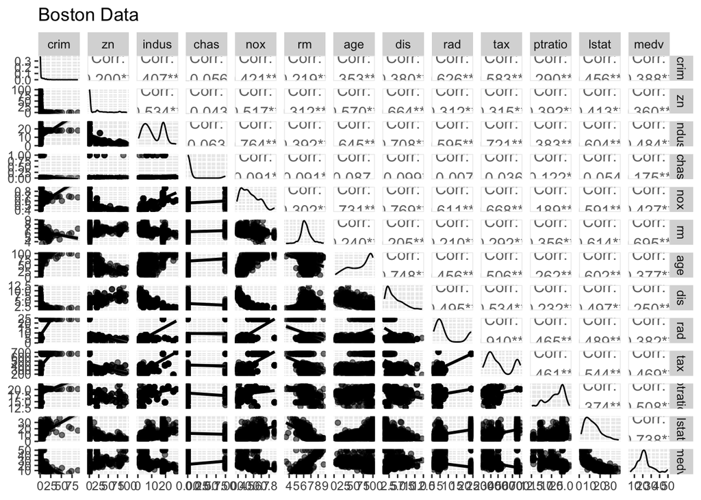

```r
library(GGally)
# Graphical summaries
ggpairs(
  data = boston,
  mapping = aes(alpha = 0.25),
  lower = list(continuous = "smooth")
) +
  labs(title = "Boston Data")
```

```r
boston <- boston %>%
  drop_na()
dim(boston)
```

```
[1] 506  13
```

**Initial split into test and non-test sets:**

```r
# For reproducibility
set.seed(425)
data_split <- initial_split(
  boston,
  prop = 0.75
)

boston_other <- training(data_split)
dim(boston_other)
```

```
[1] 379  13
```

```r
boston_test <- testing(data_split)
dim(boston_test)
```

```
[1] 127  13
```

**Recipe (R):**

```r
norm_recipe <-
  recipe(
    crim ~ .,
    data = boston_other
  ) %>%
  # create traditional dummy variables
  step_dummy(all_nominal()) %>%
  # zero-variance filter
  step_zv(all_predictors()) %>%
  # center and scale numeric data
  step_normalize(all_predictors()) %>%
  # estimate the means and standard deviations
  prep(training = boston_other, retain = TRUE)
norm_recipe
```

**Model:**

Least squares:

```r
lm_mod <-
  linear_reg() %>%
  set_engine("lm")
lm_mod
```

```
Linear Regression Model Specification (regression)

Computational engine: lm
```

Ridge:

```r
ridge_mod <-
  # mixture = 0 (ridge), mixture = 1 (lasso)
  linear_reg(penalty = tune(), mixture = 0) %>%
  set_engine("glmnet")
ridge_mod
```

```
Linear Regression Model Specification (regression)

Main Arguments:
  penalty = tune()
  mixture = 0

Computational engine: glmnet
```

Lasso:

```r
lasso_mod <-
  # mixture = 0 (ridge), mixture = 1 (lasso)
  linear_reg(penalty = tune(), mixture = 1.0) %>%
  set_engine("glmnet")
lasso_mod
```

```
Linear Regression Model Specification (regression)

Main Arguments:
  penalty = tune()
  mixture = 1

Computational engine: glmnet
```

**Workflow (R):**

Least squares:

```r
ls_lr_wf <-
  workflow() %>%
  add_model(lm_mod) %>%
  add_recipe(norm_recipe)
ls_lr_wf
```

```
══ Workflow ════════════════════════════════════════════════════════════════════
Preprocessor: Recipe
Model: linear_reg()

── Preprocessor ────────────────────────────────────────────────────────────────
3 Recipe Steps

• step_dummy()
• step_zv()
• step_normalize()

── Model ───────────────────────────────────────────────────────────────────────
Linear Regression Model Specification (regression)

Computational engine: lm
```

Ridge:

```r
ridge_lr_wf <-
  workflow() %>%
  add_model(ridge_mod) %>%
  add_recipe(norm_recipe)
ridge_lr_wf
```

```
══ Workflow ════════════════════════════════════════════════════════════════════
Preprocessor: Recipe
Model: linear_reg()

── Preprocessor ────────────────────────────────────────────────────────────────
3 Recipe Steps

• step_dummy()
• step_zv()
• step_normalize()

── Model ───────────────────────────────────────────────────────────────────────
Linear Regression Model Specification (regression)

Main Arguments:
  penalty = tune()
  mixture = 0

Computational engine: glmnet
```

Lasso:

```r
lasso_lr_wf <-
  workflow() %>%
  add_model(lasso_mod) %>%
  add_recipe(norm_recipe)
lasso_lr_wf
```

```
══ Workflow ════════════════════════════════════════════════════════════════════
Preprocessor: Recipe
Model: linear_reg()

── Preprocessor ────────────────────────────────────────────────────────────────
3 Recipe Steps

• step_dummy()
• step_zv()
• step_normalize()

── Model ───────────────────────────────────────────────────────────────────────
Linear Regression Model Specification (regression)

Main Arguments:
  penalty = tune()
  mixture = 1

Computational engine: glmnet
```

**Tuning grid:**

```r
lambda_grid <-
  grid_regular(penalty(range = c(-2, 3), trans = log10_trans()), levels = 100)
lambda_grid
```

```
# A tibble: 100 × 1
   penalty
     <dbl>
 1  0.01
 2  0.0112
 3  0.0126
 4  0.0142
 5  0.0159
 6  0.0179
 7  0.0201
 8  0.0226
 9  0.0254
10  0.0285
# ℹ 90 more rows
```

**Cross-validation (CV):**

```r
set.seed(250)
folds <- vfold_cv(boston_other, v = 10)
folds
```

```
#  10-fold cross-validation
# A tibble: 10 × 2
   splits           id
   <list>           <chr>
 1 <split [341/38]> Fold01
 2 <split [341/38]> Fold02
 3 <split [341/38]> Fold03
 4 <split [341/38]> Fold04
 5 <split [341/38]> Fold05
 6 <split [341/38]> Fold06
 7 <split [341/38]> Fold07
 8 <split [341/38]> Fold08
 9 <split [341/38]> Fold09
10 <split [342/37]> Fold10
```

**Fit cross-validation:**

least squares:

```r
# Fit the cross-validation
cv_results <- ls_lr_wf %>%
  fit_resamples(resamples = folds, metrics = metric_set(rmse))

# Summarize the results
summary(cv_results)
```

[output not shown]

[output cut: 18 more lines]

Ridge:

```r
ridge_fit <-
  ridge_lr_wf %>%
  tune_grid(
    resamples = folds,
    grid = lambda_grid
  )
ridge_fit
```

```
# Tuning results
# 10-fold cross-validation
# A tibble: 10 × 4
   splits           id     .metrics           .notes
   <list>           <chr>  <list>             <list>
 1 <split [341/38]> Fold01 <tibble [200 × 5]> <tibble [0 × 3]>
 2 <split [341/38]> Fold02 <tibble [200 × 5]> <tibble [0 × 3]>
 3 <split [341/38]> Fold03 <tibble [200 × 5]> <tibble [0 × 3]>
 4 <split [341/38]> Fold04 <tibble [200 × 5]> <tibble [0 × 3]>
 5 <split [341/38]> Fold05 <tibble [200 × 5]> <tibble [0 × 3]>
 6 <split [341/38]> Fold06 <tibble [200 × 5]> <tibble [0 × 3]>
 7 <split [341/38]> Fold07 <tibble [200 × 5]> <tibble [0 × 3]>
 8 <split [341/38]> Fold08 <tibble [200 × 5]> <tibble [0 × 3]>
 9 <split [341/38]> Fold09 <tibble [200 × 5]> <tibble [0 × 3]>
10 <split [342/37]> Fold10 <tibble [200 × 5]> <tibble [0 × 3]>
```

Lasso:

```r
lasso_fit <-
  lasso_lr_wf %>%
  tune_grid(
    resamples = folds,
    grid = lambda_grid
  )
lasso_fit
```

```
# Tuning results
# 10-fold cross-validation
# A tibble: 10 × 4
   splits           id     .metrics           .notes
   <list>           <chr>  <list>             <list>
 1 <split [341/38]> Fold01 <tibble [200 × 5]> <tibble [1 × 3]>
 2 <split [341/38]> Fold02 <tibble [200 × 5]> <tibble [1 × 3]>
 3 <split [341/38]> Fold03 <tibble [200 × 5]> <tibble [1 × 3]>
 4 <split [341/38]> Fold04 <tibble [200 × 5]> <tibble [1 × 3]>
 5 <split [341/38]> Fold05 <tibble [200 × 5]> <tibble [1 × 3]>
 6 <split [341/38]> Fold06 <tibble [200 × 5]> <tibble [1 × 3]>
 7 <split [341/38]> Fold07 <tibble [200 × 5]> <tibble [1 × 3]>
 8 <split [341/38]> Fold08 <tibble [200 × 5]> <tibble [1 × 3]>
 9 <split [341/38]> Fold09 <tibble [200 × 5]> <tibble [1 × 3]>
10 <split [342/37]> Fold10 <tibble [200 × 5]> <tibble [1 × 3]>

There were issues with some computations:

  - Warning(s) x10: A correlation computation is required, but `estimate` is constant...

Run `show_notes(.Last.tune.result)` for more information.
```

**Visualize CV criterion:**

Least squares:

```r
# Collect cross-validation metrics
cv_metrics <- collect_metrics(cv_results)
cv_metrics
```

```
# A tibble: 1 × 6
  .metric .estimator  mean     n std_err .config
  <chr>   <chr>      <dbl> <int>   <dbl> <chr>
1 rmse    standard    5.69    10    1.27 Preprocessor1_Model1
```

```r
cv_rmse_ls <- cv_metrics$mean
cv_rmse_ls
```

```
[1] 5.693454
```

Ridge:

```
# A tibble: 200 × 7
   penalty .metric .estimator  mean     n std_err .config
     <dbl> <chr>   <chr>      <dbl> <int>   <dbl> <chr>
 1  0.01   rmse    standard   5.58     10  1.33   Preprocessor1_Model001
 2  0.01   rsq     standard   0.628    10  0.0510 Preprocessor1_Model001
 3  0.0112 rmse    standard   5.58     10  1.33   Preprocessor1_Model002
 4  0.0112 rsq     standard   0.628    10  0.0510 Preprocessor1_Model002
 5  0.0126 rmse    standard   5.58     10  1.33   Preprocessor1_Model003
 6  0.0126 rsq     standard   0.628    10  0.0510 Preprocessor1_Model003
 7  0.0142 rmse    standard   5.58     10  1.33   Preprocessor1_Model004
 8  0.0142 rsq     standard   0.628    10  0.0510 Preprocessor1_Model004
 9  0.0159 rmse    standard   5.58     10  1.33   Preprocessor1_Model005
10  0.0159 rsq     standard   0.628    10  0.0510 Preprocessor1_Model005
# ℹ 190 more rows
```

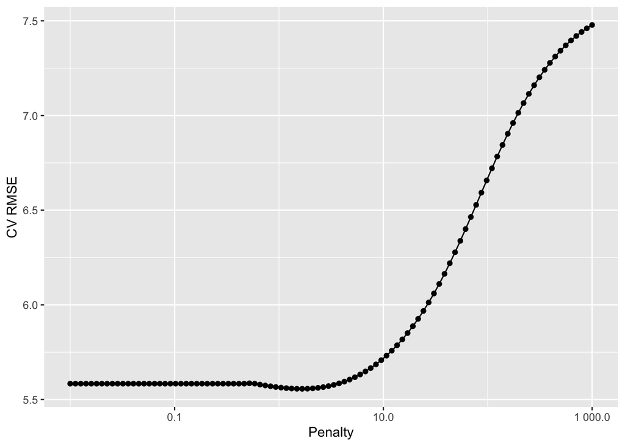

```r
ridge_fit %>%
  collect_metrics() %>%
  print(width = Inf) %>%
  filter(.metric == "rmse") %>%
  ggplot(mapping = aes(x = penalty, y = mean)) +
  geom_point() +
  geom_line() +
  labs(x = "Penalty", y = "CV RMSE") +
  scale_x_log10(labels = scales::label_number())
```

```r
cv_rmse_ridge <- ridge_fit %>%
  collect_metrics() %>%
  print(width = Inf) %>%
  filter(.metric == "rmse") %>%
  pull(mean)
```

```
# A tibble: 200 × 7
   penalty .metric .estimator  mean     n std_err .config
     <dbl> <chr>   <chr>      <dbl> <int>   <dbl> <chr>
 1  0.01   rmse    standard   5.58     10  1.33   Preprocessor1_Model001
 2  0.01   rsq     standard   0.628    10  0.0510 Preprocessor1_Model001
 3  0.0112 rmse    standard   5.58     10  1.33   Preprocessor1_Model002
 4  0.0112 rsq     standard   0.628    10  0.0510 Preprocessor1_Model002
 5  0.0126 rmse    standard   5.58     10  1.33   Preprocessor1_Model003
 6  0.0126 rsq     standard   0.628    10  0.0510 Preprocessor1_Model003
 7  0.0142 rmse    standard   5.58     10  1.33   Preprocessor1_Model004
 8  0.0142 rsq     standard   0.628    10  0.0510 Preprocessor1_Model004
 9  0.0159 rmse    standard   5.58     10  1.33   Preprocessor1_Model005
10  0.0159 rsq     standard   0.628    10  0.0510 Preprocessor1_Model005
# ℹ 190 more rows
```

```r
cv_rmse_ridge
```

```
  [1] 5.583795 5.583795 5.583795 5.583795 5.583795 5.583795 5.583795 5.583795
  [9] 5.583795 5.583795 5.583795 5.583795 5.583795 5.583795 5.583795 5.583795
 [17] 5.583795 5.583795 5.583795 5.583795 5.583795 5.583795 5.583795 5.583795
 [25] 5.583795 5.583795 5.583795 5.583795 5.583795 5.583795 5.583795 5.583795
 [33] 5.583795 5.583795 5.585801 5.583984 5.578985 5.574302 5.569991 5.566124
 [41] 5.562833 5.560112 5.558175 5.556970 5.556663 5.557300 5.558940 5.561688
 [49] 5.565688 5.570882 5.577348 5.585216 5.594564 5.605424 5.617919 5.632164
 [57] 5.648124 5.665918 5.685723 5.707667 5.731717 5.757853 5.786392 5.817492
 [65] 5.851144 5.887199 5.926085 5.967956 6.012678 6.059991 6.110344 6.163715
 [73] 6.219693 6.277695 6.338000 6.400332 6.463937 6.527921 6.592471 6.657171
 [81] 6.721133 6.783436 6.844352 6.903609 6.960488 7.014314 7.065547 7.114163
 [89] 7.159731 7.201888 7.241197 7.277811 7.311536 7.342227 7.370430 7.396360
 [97] 7.419955 7.441187 7.460505 7.478110
```

Lasso:

```
# A tibble: 200 × 7
   penalty .metric .estimator  mean     n std_err .config
     <dbl> <chr>   <chr>      <dbl> <int>   <dbl> <chr>
 1  0.01   rmse    standard   5.68     10  1.28   Preprocessor1_Model001
 2  0.01   rsq     standard   0.620    10  0.0485 Preprocessor1_Model001
 3  0.0112 rmse    standard   5.68     10  1.28   Preprocessor1_Model002
 4  0.0112 rsq     standard   0.620    10  0.0485 Preprocessor1_Model002
 5  0.0126 rmse    standard   5.67     10  1.28   Preprocessor1_Model003
 6  0.0126 rsq     standard   0.621    10  0.0486 Preprocessor1_Model003
 7  0.0142 rmse    standard   5.67     10  1.28   Preprocessor1_Model004
 8  0.0142 rsq     standard   0.621    10  0.0487 Preprocessor1_Model004
 9  0.0159 rmse    standard   5.67     10  1.29   Preprocessor1_Model005
10  0.0159 rsq     standard   0.621    10  0.0488 Preprocessor1_Model005
# ℹ 190 more rows
```

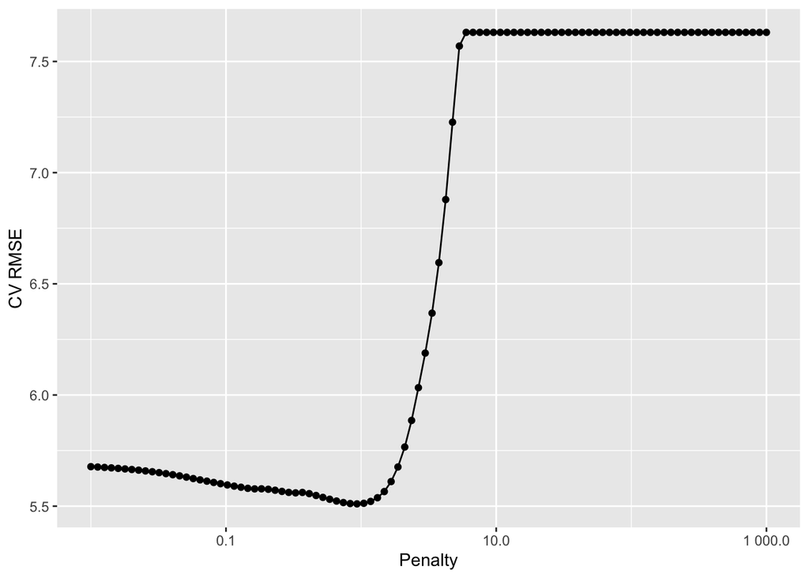

```r
lasso_fit %>%
  collect_metrics() %>%
  print(width = Inf) %>%
  filter(.metric == "rmse") %>%
  ggplot(mapping = aes(x = penalty, y = mean)) +
  geom_point() +
  geom_line() +
  labs(x = "Penalty", y = "CV RMSE") +
  scale_x_log10(labels = scales::label_number())
```

```r
cv_rmse_lasso <- lasso_fit %>%
  collect_metrics() %>%
  print(width = Inf) %>%
  filter(.metric == "rmse") %>%
  pull(mean)
```

```
# A tibble: 200 × 7
   penalty .metric .estimator  mean     n std_err .config
     <dbl> <chr>   <chr>      <dbl> <int>   <dbl> <chr>
 1  0.01   rmse    standard   5.68     10  1.28   Preprocessor1_Model001
 2  0.01   rsq     standard   0.620    10  0.0485 Preprocessor1_Model001
 3  0.0112 rmse    standard   5.68     10  1.28   Preprocessor1_Model002
 4  0.0112 rsq     standard   0.620    10  0.0485 Preprocessor1_Model002
 5  0.0126 rmse    standard   5.67     10  1.28   Preprocessor1_Model003
 6  0.0126 rsq     standard   0.621    10  0.0486 Preprocessor1_Model003
 7  0.0142 rmse    standard   5.67     10  1.28   Preprocessor1_Model004
 8  0.0142 rsq     standard   0.621    10  0.0487 Preprocessor1_Model004
 9  0.0159 rmse    standard   5.67     10  1.29   Preprocessor1_Model005
10  0.0159 rsq     standard   0.621    10  0.0488 Preprocessor1_Model005
# ℹ 190 more rows
```

```r
cv_rmse_lasso
```

```
  [1] 5.677683 5.676053 5.674166 5.672196 5.669942 5.667520 5.664872 5.661946
  [9] 5.658515 5.654874 5.650820 5.646401 5.641543 5.636357 5.630621 5.624214
 [17] 5.618267 5.612488 5.606666 5.601173 5.595448 5.590114 5.585131 5.580226
 [25] 5.577754 5.578074 5.576001 5.571627 5.566435 5.561916 5.559828 5.561751
 [33] 5.556398 5.548063 5.539564 5.531124 5.523086 5.516234 5.511773 5.510371
 [41] 5.512926 5.521470 5.537982 5.565702 5.610697 5.676324 5.766028 5.885531
 [49] 6.032917 6.188469 6.368104 6.595204 6.878912 7.226891 7.569300 7.630839
 [57] 7.630839 7.630839 7.630839 7.630839 7.630839 7.630839 7.630839 7.630839
 [65] 7.630839 7.630839 7.630839 7.630839 7.630839 7.630839 7.630839 7.630839
 [73] 7.630839 7.630839 7.630839 7.630839 7.630839 7.630839 7.630839 7.630839
 [81] 7.630839 7.630839 7.630839 7.630839 7.630839 7.630839 7.630839 7.630839
 [89] 7.630839 7.630839 7.630839 7.630839 7.630839 7.630839 7.630839 7.630839
 [97] 7.630839 7.630839 7.630839 7.630839
```

**Show the top 5 models ($\lambda$values):**

Ridge:

```r
ridge_fit %>%
  show_best("rmse")
```

```
# A tibble: 5 × 7
  penalty .metric .estimator  mean     n std_err .config
    <dbl> <chr>   <chr>      <dbl> <int>   <dbl> <chr>
1    1.67 rmse    standard    5.56    10    1.38 Preprocessor1_Model045
2    1.48 rmse    standard    5.56    10    1.37 Preprocessor1_Model044
3    1.87 rmse    standard    5.56    10    1.38 Preprocessor1_Model046
4    1.32 rmse    standard    5.56    10    1.37 Preprocessor1_Model043
5    2.10 rmse    standard    5.56    10    1.39 Preprocessor1_Model047
```

Lasso:

```r
lasso_fit %>%
  show_best("rmse")
```

```
# A tibble: 5 × 7
  penalty .metric .estimator  mean     n std_err .config
    <dbl> <chr>   <chr>      <dbl> <int>   <dbl> <chr>
1   0.933 rmse    standard    5.51    10    1.46 Preprocessor1_Model040
2   0.830 rmse    standard    5.51    10    1.45 Preprocessor1_Model039
3   1.05  rmse    standard    5.51    10    1.47 Preprocessor1_Model041
4   0.739 rmse    standard    5.52    10    1.44 Preprocessor1_Model038
5   1.18  rmse    standard    5.52    10    1.48 Preprocessor1_Model042
```

**Select the best model:**

Ridge:

```r
best_ridge <- ridge_fit %>%
  select_best("rmse")
best_ridge
```

```
# A tibble: 1 × 2
  penalty .config
    <dbl> <chr>
1    1.67 Preprocessor1_Model045
```

Lasso:

```r
best_lasso <- lasso_fit %>%
  select_best("rmse")
best_lasso
```

```
# A tibble: 1 × 2
  penalty .config
    <dbl> <chr>
1   0.933 Preprocessor1_Model040
```

**Finalize our model:**

Final workflow:

Ridge:

```r
ridge_final_wf <- ridge_lr_wf %>%
  finalize_workflow(best_ridge)
ridge_final_wf
```

```
══ Workflow ════════════════════════════════════════════════════════════════════
Preprocessor: Recipe
Model: linear_reg()

── Preprocessor ────────────────────────────────────────────────────────────────
3 Recipe Steps

• step_dummy()
• step_zv()
• step_normalize()

── Model ───────────────────────────────────────────────────────────────────────
Linear Regression Model Specification (regression)

Main Arguments:
  penalty = 1.66810053720006
  mixture = 0

Computational engine: glmnet
```

Lasso:

```r
lasso_final_wf <- lasso_lr_wf %>%
  finalize_workflow(best_lasso)
lasso_final_wf
```

```
══ Workflow ════════════════════════════════════════════════════════════════════
Preprocessor: Recipe
Model: linear_reg()

── Preprocessor ────────────────────────────────────────────────────────────────
3 Recipe Steps

• step_dummy()
• step_zv()
• step_normalize()

── Model ───────────────────────────────────────────────────────────────────────
Linear Regression Model Specification (regression)

Main Arguments:
  penalty = 0.93260334688322
  mixture = 1

Computational engine: glmnet
```

**Fit the whole training set, then predict the test cases**

Least squares:

```r
ls_final_fit <-
  ls_lr_wf %>%
  last_fit(data_split)
```

Ridge:

```r
ridge_final_fit <-
  ridge_final_wf %>%
  last_fit(data_split)
ridge_final_fit
```

```
# Resampling results
# Manual resampling
# A tibble: 1 × 6
  splits            id               .metrics .notes   .predictions .workflow
  <list>            <chr>            <list>   <list>   <list>       <list>
1 <split [379/127]> train/test split <tibble> <tibble> <tibble>     <workflow>
```

Lasso:

```r
lasso_final_fit <-
  lasso_final_wf %>%
  last_fit(data_split)
lasso_final_fit
```

```
# Resampling results
# Manual resampling
# A tibble: 1 × 6
  splits            id               .metrics .notes   .predictions .workflow
  <list>            <chr>            <list>   <list>   <list>       <list>
1 <split [379/127]> train/test split <tibble> <tibble> <tibble>     <workflow>
```

**Test metrics:**

Least square:

```r
ls_final_fit %>% collect_metrics()
```

```
# A tibble: 2 × 4
  .metric .estimator .estimate .config
  <chr>   <chr>          <dbl> <chr>
1 rmse    standard       5.51  Preprocessor1_Model1
2 rsq     standard       0.515 Preprocessor1_Model1
```

```r
test_rmse_ls <- ls_final_fit %>%
  collect_metrics() %>%
  filter(.metric == "rmse") %>%
  pull(.estimate)
test_rmse_ls
```

```
[1] 5.509317
```

Ridge:

```r
ridge_final_fit %>% collect_metrics()
```

```
# A tibble: 2 × 4
  .metric .estimator .estimate .config
  <chr>   <chr>          <dbl> <chr>
1 rmse    standard       5.51  Preprocessor1_Model1
2 rsq     standard       0.512 Preprocessor1_Model1
```

```r
test_rmse_ridge <- ridge_final_fit %>%
  collect_metrics() %>%
  filter(.metric == "rmse") %>%
  pull(.estimate)
test_rmse_ridge
```

```
[1] 5.508474
```

Lasso:

```r
lasso_final_fit %>% collect_metrics()
```

```
# A tibble: 2 × 4
  .metric .estimator .estimate .config
  <chr>   <chr>          <dbl> <chr>
1 rmse    standard       5.57  Preprocessor1_Model1
2 rsq     standard       0.513 Preprocessor1_Model1
```

```r
test_rmse_lasso <- lasso_final_fit %>%
  collect_metrics() %>%
  filter(.metric == "rmse") %>%
  pull(.estimate)
test_rmse_lasso
```

```
[1] 5.566094
```

```r
# Create a tibble to store the results
results_df <- tibble(
  Method = c("LS", "Ridge", "Lasso"),
  CV_RMSE = c(cv_rmse_ls, mean(cv_rmse_ridge), mean(cv_rmse_lasso)),
  Test_RMSE = c(test_rmse_ls, test_rmse_ridge, test_rmse_lasso)
)

# Print the final results
print(results_df)
```

[output not shown]

**(b)** Propose a model (or set of models) that seem to perform well on this data set, and justify your answer. Make sure that you are evaluating model performance using validation set error, crossvalidation, or some other reasonable alternative, as opposed to using training error.

**Answer:**

Based on the results of test RMSE, the Ridge model seems to perform the best on this data set since it has the lowest test RMSE. Because the Ridge model uses a penalty term to shrink the coefficients of the features towards zero, it is better at handling multicollinearity than the Lasso model. The Lasso model performs the worst on this data set, which is likely due to the fact that it selects a subset of the features and sets the coefficients of the other features to zero. The least squares model performs better than the Lasso model, but not as well as the Ridge model. This is likely due to the fact that the least squares model does not use a penalty term to shrink the coefficients of the features towards zero, and therefore is not as good at handling multicollinearity as the Ridge model.

**(c)** Does your chosen model involve all of the features in the data set? Why or why not?

## 9 Bonus question (20pts)

Consider a linear regression, fit by least squares to a set of training data $(x_1, y_1), \ldots, (x_N, y_N)$ drawn at random from a population. Let $\hat \beta$ be the least squares estimate. Suppose we have some test data $(\tilde{x}_1, \tilde{y}_1), \ldots, (\tilde{x}_M, \tilde{y}_M)$ drawn at random from the same population as the training data. If $R_{\text{train}}(\beta) = \frac{1}{N} \sum_{i=1}^N (y_i - \beta^T x_i)^2$ and $R_{\text{test}}(\beta) = \frac{1}{M} \sum_{i=1}^M (\tilde{y}_i - \beta^T \tilde{x}_i)^2$. Show that

$$\operatorname{E}[R_{\text{train}}(\hat{\beta})] < \operatorname{E}[R_{\text{test}}(\hat{\beta})].$$
**Answer:**

Since the training data and test data are drawn at random from the same population. Therefore, we have

$$min_\beta\ \frac{1}{N} \sum_{i=1}^N (y_i - \beta^T x_i)^2 = min\ \frac{1}{M} \sum_{i=1}^M (\tilde{y}_i - \beta^T \tilde{x}_i)^2$$

Thus, we have

$$\hat \beta = \tilde \beta$$
Therefore, we have

$$\operatorname{E}[R_{\text{train}}(\hat{\beta})] = \operatorname{E}[R_{\text{test}}(\tilde{\beta})].$$

which is the minimum.

When we replace $\tilde\beta$ with $\hat\beta$, we cannot get the minimum value. Therefore, we have

$$\operatorname{E}[R_{\text{train}}(\hat{\beta})] < \operatorname{E}[R_{\text{test}}(\hat{\beta})]$$